# Análisis de Datos de viviendas

2024-05-15

## Introduccion P-set4

Aquí se presentará un breve análisis de los precios de vivienda utilizando los datos proporcionados de la página “https://eduard-martinez.github.io/pset-4.html”. Este analisis sera realizado por Juan David Prada Amaya con codigo 202112612 y David Eduardo Bonilla con codigo 202015465.

## Extraemos la informacion de la pagina web

- La variable url nos guarda la dirrecion de la pagina en donde se encuentran los datos.
- La variable html nos lee el objeto que acabamos de guardar en la anterior variable.

```r
url = "https://eduard-martinez.github.io/pset-4.html"
html <- read_html(url)
```

La pagina posee varios URLs por lo cual debemos de leer cada uno y guardarlo - La variable html nos lee el objeto que acabamos de guardar en la anterior variable.

```r
url_full <- html %>% html_elements("a")
```

Filtramos los URLs los cuales posean la palabra “propiedad” y guardamos los resultados en url_subset

```r
url_subset <- url_full %>% html_attr("href") %>% str_subset("propiedad")
```

Extraemos los datos coordenadas y precio del HTML de cada URL

```r
lista_tablas <- list()
for (i in seq_along(url_subset)) {
  tablas <- read_html(url_subset[i]) %>% html_table() %>% as.data.frame()
  indice <- c(8, 10, 11)

  # Extraer las columnas seleccionadas y mantener nombres de columnas
  info <- tablas[, indice, drop = FALSE]

  # Asegurar que las filas tienen nombres (puede ajustarse según necesidad)
  rownames(info) <- paste("Row", 1:nrow(info), sep = "_")

  # Agregar el dataframe a la lista
  lista_tablas[[i]] <- info
}
print(lista_tablas)
```

[output not shown]

[output cut: 824 more lines]

[output not shown]

Convertimos la informacion obtenida hasta el momento en un dataframe y lo guardamos en la variable db_house

```r
db_house <- rbindlist(lista_tablas)
```

## Resultados

Se pinta un mapa para presentar resultados obtenidos

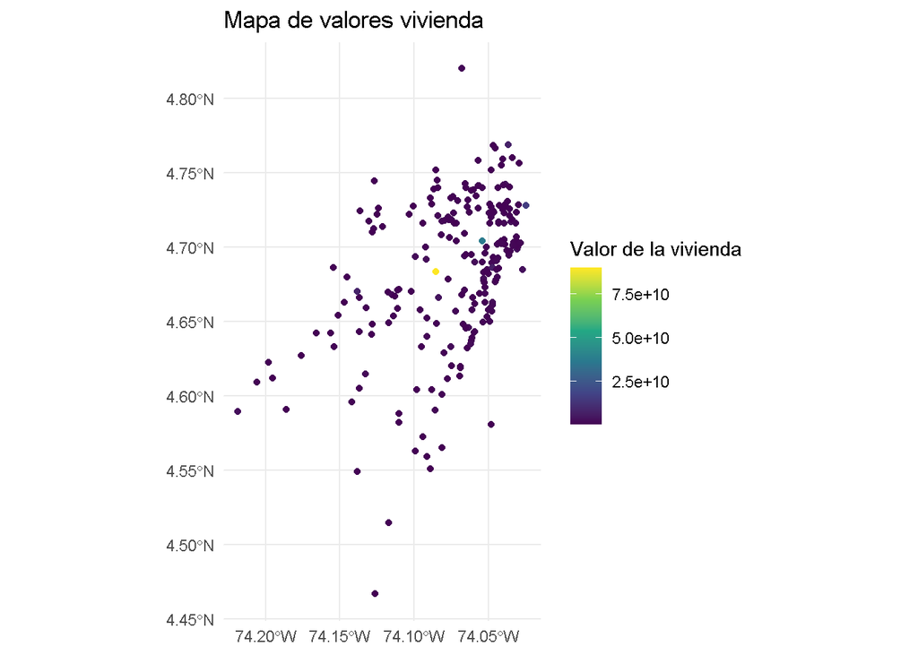

```r
map <- ggplot(data =sf_house)+geom_sf(aes(color= price))+
  scale_color_viridis_c(option = "viridis", name = "Valor de la vivienda")+
  labs(title = "Mapa de valores vivienda")+ theme_minimal()

print(map)
```

Se guarda en un archivo PDF

```r
ggsave("mapa_valores_vivienda.pdf", plot=map, device = "pdf", width = 10, height = 7)
```

##Analisis

Un poco de estadisticas descripticas acerca de los resultados obtenidos

```r
estas <- summary(db_house$price)
estas
```

```
##      Min.   1st Qu.    Median      Mean   3rd Qu.      Max.
## 1.900e+07 3.000e+08 4.775e+08 1.400e+09 8.885e+08 9.000e+10
```

- Min.: El valor mínimo en el conjunto de datos es 19,000,000.
- 1st Qu.: El primer cuartil, que es el valor que separa el 25% inferior del conjunto de datos, es 300,000,000.
- Median: La mediana, que es el valor que separa el 50% inferior del conjunto de datos del 50% superior, es 477,500,000.
- Mean: La media, que es el promedio de todos los valores del conjunto de datos, es 1,400,000,000. 3rd Qu.: El tercer cuartil, que es el valor que separa el 75% inferior del conjunto de datos, es 888,500,000.
- Max.: El valor máximo en el conjunto de datos es 90,000,000,000.